```r
setwd("C:\\Users\\ARB226.PITT\\Downloads")
df <- read.csv("hw3_adult.csv", header = TRUE)
```

QUESTION #1 How did you choose which variables to use? Which techniques did you use for feature selection? What are some of your most important variables? Use evidence to support your answer.

```r
library(MASS)
fsel<-lda(df$Salary ~ . , df)
fsel
```

```
## Call:
## lda(df$Salary ~ ., data = df)
##
## Prior probabilities of groups:
##     <=50K      >50K
## 0.7503752 0.2496248
##
## Group means:
##             Age Workclass Federal-gov Workclass Local-gov
##  <=50K 37.10600            0.02066667          0.07000000
##  >50K  44.14429            0.03807615          0.06012024
##        Workclass Private Workclass Self-emp-inc Workclass Self-emp-not-inc
##  <=50K         0.7093333             0.01733333                 0.07333333
##  >50K          0.6352705             0.10220441                 0.09018036
##        Workclass State-gov Workclass Without-pay   Fnlwgt Education 11th
##  <=50K          0.03400000          0.0006666667 192623.8     0.05066667
##  >50K           0.05210421          0.0000000000 185797.9     0.01002004
##        Education 12th Education 1st-4th Education 5th-6th
##  <=50K    0.009333333       0.007333333        0.01133333
##  >50K     0.004008016       0.000000000        0.00000000
##        Education 7th-8th Education 9th Education Assoc-acdm
##  <=50K       0.019333333    0.01866667           0.03066667
##  >50K        0.008016032    0.00000000           0.04208417
##        Education Assoc-voc Education Bachelors Education Doctorate
##  <=50K          0.04200000           0.1313333          0.00200000
##  >50K           0.04408818           0.2905812          0.03607214
##        Education HS-grad Education Masters Education Preschool
##  <=50K          0.362000        0.03733333         0.001333333
##  >50K           0.254509        0.11422846         0.000000000
##        Education Prof-school Education Some-college Education_num
##  <=50K           0.006666667              0.2333333      9.653333
##  >50K            0.038076152              0.1503006     11.490982
##        Marital_status Married-AF-spouse Marital_status Married-civ-spouse
##  <=50K                      0.001333333                         0.3346667
##  >50K                       0.000000000                         0.8617234
##        Marital_status Married-spouse-absent Marital_status Never-married
##  <=50K                          0.016666667                   0.41333333
##  >50K                           0.004008016                   0.05811623
##        Marital_status Separated Marital_status Widowed
##  <=50K              0.030666667             0.03933333
```

[output cut: 158 more lines]

```
## Native_country Mexico                     -7.820465e-01
## Native_country Nicaragua                  -2.469207e+00
## Native_country Outlying-US(Guam-USVI-etc)  1.079337e-01
## Native_country Peru                       -2.148471e+00
## Native_country Philippines                 8.772132e-02
## Native_country Poland                     -9.921941e-01
## Native_country Portugal                    1.644259e-01
## Native_country Puerto-Rico                -5.222568e-01
## Native_country Scotland                   -1.346904e+00
## Native_country South                       8.564623e-01
## Native_country Taiwan                      5.000702e-01
## Native_country Thailand                   -7.940359e-01
## Native_country Trinadad&Tobago            -1.279012e+00
## Native_country United-States              -1.727468e-02
## Native_country Yugoslavia                 -1.907181e+00
```

```r
chisq.test(df$Workclass, df$Salary, correct = FALSE)
```

```
##
##  Pearson's Chi-squared test
##
## data:  df$Workclass and df$Salary
## X-squared = 99.812, df = 7, p-value < 2.2e-16
```

```r
chisq.test(df$Marital_status, df$Salary, correct = FALSE)
```

```
##
##  Pearson's Chi-squared test
##
## data:  df$Marital_status and df$Salary
## X-squared = 422.07, df = 6, p-value < 2.2e-16
```

```r
chisq.test(df$Education, df$Salary, correct = FALSE)
```

```
##
##  Pearson's Chi-squared test
##
## data:  df$Education and df$Salary
## X-squared = 237.26, df = 15, p-value < 2.2e-16
```

```r
chisq.test(df$Occupation, df$Salary, correct = FALSE)
```

```
##
##  Pearson's Chi-squared test
##
## data:  df$Occupation and df$Salary
## X-squared = 269.4, df = 14, p-value < 2.2e-16
```

```r
chisq.test(df$Race, df$Salary, correct = FALSE)
```

```
##
##  Pearson's Chi-squared test
##
## data:  df$Race and df$Salary
## X-squared = 31.402, df = 4, p-value = 2.535e-06
```

```r
chisq.test(df$Sex, df$Salary, correct = FALSE)
```

```
##
##  Pearson's Chi-squared test
##
## data:  df$Sex and df$Salary
## X-squared = 71.151, df = 1, p-value < 2.2e-16
```

```r
chisq.test(df$Native_country, df$Salary, correct = FALSE)
```

```
##
##  Pearson's Chi-squared test
##
## data:  df$Native_country and df$Salary
## X-squared = 48.689, df = 36, p-value = 0.07702
```

```r
library(rsample)
library(glmnet)
library(caret)
library(dplyr)
set.seed(99)
Saltraintest <- initial_split(df, prop = 0.90)
Saltrain <- training(Saltraintest)
Saltest  <- testing(Saltraintest)

Saltargettrain <- Saltrain[, c("Salary")]
Saltargettest <- Saltest[, c("Salary")]

library(glmnet)

dfglm1 = glm(Salary ~ . , family = binomial, data = Saltrain)
P_TEST = predict(dfglm1, newdata = Saltest , type = "response")
Saltest <- Saltest %>%
  mutate(P_RESP = ifelse(P_TEST >= 0.5, 1, 0))
predictedSal <- Saltest$P_RESP

a <- sub(" >50K","1",Saltargettest)
b <- sub(" <=50K","0",a)
Saltargettest <- b

table(Saltargettest, predictedSal)
```

```
##              predictedSal
## Saltargettest   0   1
##             0 135  15
##             1  28  21
```

```r
df_test <- data.frame(Saltargettest, predictedSal)

df_test <- df_test %>%
  mutate(CORRECT_test = ifelse(predictedSal == Saltargettest, 1, 0))

CORRECT_test <- sum(df_test$CORRECT_test)/99
CORRECT_test
```

```
## [1] 1.575758
```

```r
a <- sub(" >50K","1",Saltargettrain)
b <- sub(" <=50K","0",a)
Salary_target_train <- b

P_TRAIN = predict(dfglm1, newdata = Saltrain, type = "response")
Saltrain <- Saltrain %>%
  mutate(P_RESP2 = ifelse(P_TRAIN >= 0.5, 1, 0))
predictedSal2 <- Saltrain$P_RESP2
table(Saltargettrain, predictedSal2)
```

```
##               predictedSal2
## Saltargettrain    0    1
##          <=50K 1256   94
##          >50K   158  292
```

```r
df_train <- data.frame(Saltargettrain, predictedSal2)
df_train <- df_train %>%
  mutate(CORRECT_train = ifelse(predictedSal2 == Saltargettrain, 1, 0))

CORRECT_train <- sum(df_train$CORRECT_train)/1900
CORRECT_train
```

```
## [1] 0
```

```r
set.seed(99)
Salarytraintestsplit <- initial_split(df, prop = 0.90)
Salarytrain2 <- training(Salarytraintestsplit)
Salarytest2 <- testing(Salarytraintestsplit)

Salarytargettrain2 <- Salarytrain2[, c("Salary")]
Salarytargettest2 <- Salarytest2[, c("Salary")]

Salarytrainsc <- data.frame(scale(Salarytrain2[, c("Age", "Fnlwgt", "Education_num", "Captical_gain", "Captial_loss", "Hours_per_week")]))
Salarytestsc <- data.frame(scale(Salarytest2[, c("Age", "Fnlwgt", "Education_num", "Captical_gain", "Captial_loss", "Hours_per_week")]))
```

```r
library(class)

nr5 <- knn(train = Salarytrainsc, test = Salarytestsc, cl = Salarytrain2$Salary, k = 5, prob = TRUE)

Salarytestdf <- data.frame(Salarytest2$Salary, nr5)

Salarytestdf <- Salarytestdf %>%
  mutate(CORRECT_KNN5 = ifelse(Salarytestdf$Salarytest2.Salary == Salarytestdf$nr5, 1, 0))

KNN5_CORRECT_test <- sum(Salarytestdf$CORRECT_KNN5)/99
KNN5_CORRECT_test
```

```
## [1] 1.525253
```

```r
nr52 <- knn(train = Salarytrainsc, test = Salarytrainsc, cl = Salarytrain2$Salary, k = 5, prob = TRUE)

Salarytraindf <- data.frame(Salarytrain2$Salary, nr52)

Salarytraindf <- Salarytraindf %>%
  mutate(CORRECT_KNN5_2 = ifelse(Salarytraindf$Salarytrain2.Salary == Salarytraindf$nr52, 1, 0))

KNN5_CORRECT_train <- sum(Salarytraindf$CORRECT_KNN5_2)/1900
KNN5_CORRECT_train
```

```
## [1] 0.8036842
```

QUESTION #2 How do your models perform on training vs. testing data? Is your model overfit? How can you tell? Which techniques did you use to validate your model? Are you confident in your model? Why or why not?

ANSWER #2

QUESTION #3 Plot the ROC curves for both of your models.

What is the AUC for your models? Which model performs better in terms of AUC?

From the below code and figure, we clearly see that Logistic regression has higher AUC, thus it is performing better.

```r
library(pROC)
```

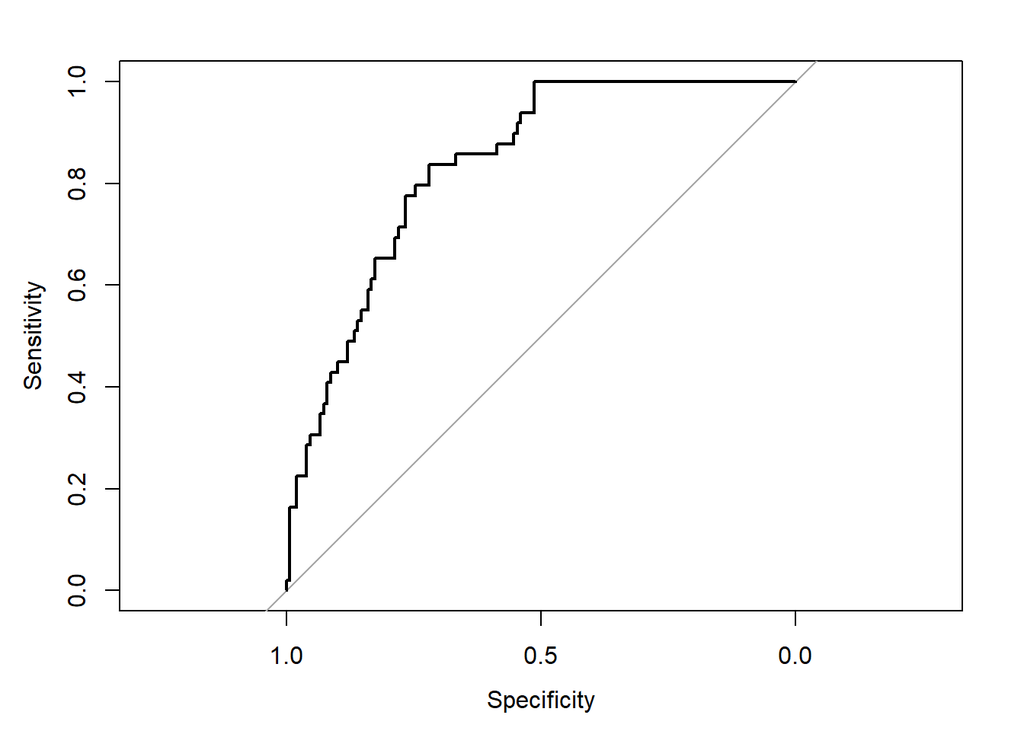

```r
Salaryrocplot <- plot(roc(Saltest$Salary, P_TEST))
```

```r
Salaryrocplot
```

```
##
## Call:
## roc.default(response = Saltest$Salary, predictor = P_TEST)
##
## Data: P_TEST in 150 controls (Saltest$Salary  <=50K) < 49 cases (Saltest$Salary  >50K).
## Area under the curve: 0.8358
```

```r
Salaryroc <- roc(Saltest$Salary, P_TEST)
Salaryauc <- auc(Salaryroc)
Salaryauc
```

```
## Area under the curve: 0.8358
```

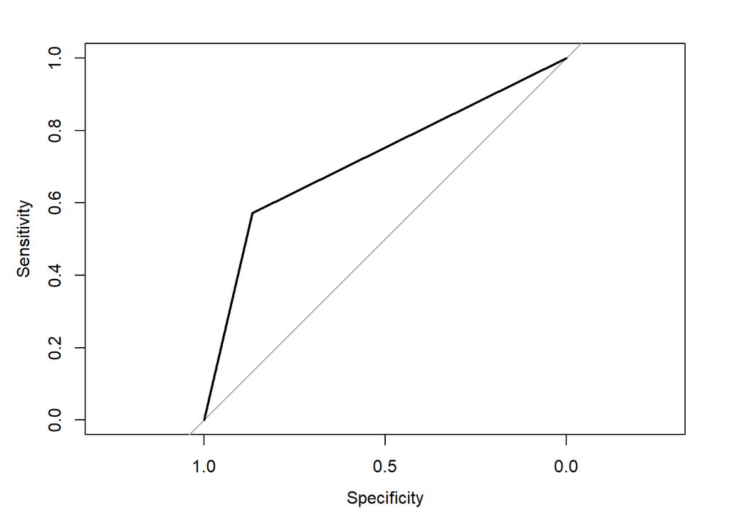

```r
Salaryrocplot2 <- plot(roc(Salarytest2$Salary, Salarytestdf$CORRECT_KNN5))
```

```r
Salaryrocplot2
```

```
##
## Call:
## roc.default(response = Salarytest2$Salary, predictor = Salarytestdf$CORRECT_KNN5)
##
## Data: Salarytestdf$CORRECT_KNN5 in 150 controls (Salarytest2$Salary  <=50K) > 49 cases (Salarytest2$Salary  >50K).
## Area under the curve: 0.719
```

```r
Salaryroc2 <- roc(Salarytest2$Salary, Salarytestdf$CORRECT_KNN5)
Salaryauc2 <- auc(Salaryroc2)
Salaryauc2
```

```
## Area under the curve: 0.719
```

Create a confusion matrix on your testing data to and answer the following questions:

What is the accuracy of your models?

What is the precision of your model?

What is the negative predictive value of your model?

What is the sensitivity of your model?

What is the specificity of your model?

What is the F-1 score of your model?

```r
table(Saltargettest, predictedSal)
```

```
##              predictedSal
## Saltargettest   0   1
##             0 135  15
##             1  28  21
```

```r
table(Salarytargettest2, Salarytestdf$nr5)
```

```
##
## Salarytargettest2  <=50K  >50K
##             <=50K    130    20
##             >50K      28    21
```

```r
library(MLmetrics)
#GLM
Accuracy(y_pred = predictedSal, y_true = Saltargettest)
```

```
## [1] 0.7839196
```

```r
Precision(y_true = Saltargettest, y_pred = predictedSal, positive = NULL)
```

```
## [1] 0.8282209
```

```r
Sensitivity(y_true = Saltargettest, y_pred = predictedSal, positive = NULL)
```

```
## [1] 0.9
```

```r
Specificity(y_true = Saltargettest, y_pred = predictedSal, positive = NULL)
```

```
## [1] 0.4285714
```

```r
F1_Score(y_true = Saltargettest, y_pred = predictedSal, positive = NULL)
```

```
## [1] 0.8626198
```

```r
#KNN
Accuracy(y_pred = Salarytestdf$nr5, y_true = Salarytargettest2)
```

```
## [1] 0.758794
```

```r
Precision(y_true = Salarytargettest2, y_pred = Salarytestdf$nr5, positive = NULL)
```

```
## [1] 0.8227848
```

```r
Sensitivity(y_true = Salarytargettest2, y_pred = Salarytestdf$nr5, positive = NULL)
```

```
## [1] 0.8666667
```

```r
Specificity(y_true = Salarytargettest2, y_pred = Salarytestdf$nr5, positive = NULL)
```

```
## [1] 0.4285714
```

```r
F1_Score(y_true = Salarytargettest2, y_pred = Salarytestdf$nr5, positive = NULL)
```

```
## [1] 0.8441558
```

QUESTION 5 How did you choose your threshold for classification? Based on question 4, what are some good things about your model? What are some limitations of your model?

ANSWER#5

The threshold selection is done by starting from 0.5 and trying trial and error to get the best result. Both Logistic Regression and KNN have similar features in terms of model performance! Good features: overall performance, sensitivity, f1 score, which means better ability to predict True Postives. Limitations: low specificity bad at predicting the True Negatives.